# Massachusetts Bridge Condition Report

Published

May 17, 2026

## Overview

This report summarizes the structural condition of **5,311 bridges** in Massachusetts, based on 2025 National Bridge Inventory (NBI) data. Each bridge is rated on three components — deck, superstructure, and substructure — using a 0–9 scale. The overall `BRIDGE_CONDITION` classification (Good / Fair / Poor) is derived from the lowest of those three component ratings.

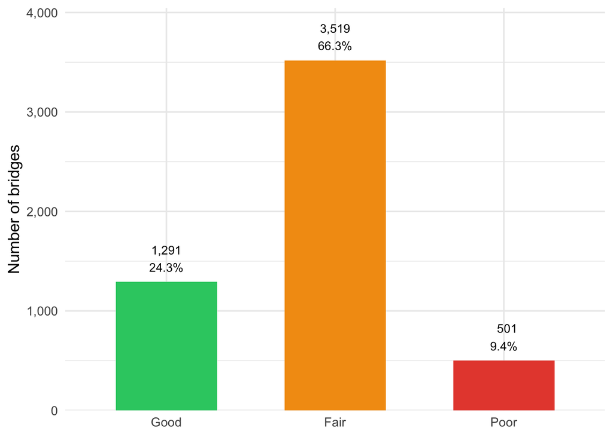

Figure 1: Overall bridge condition across Massachusetts.

**Warning**

**501 bridges** (9.4% of total) are rated **Poor** — meaning at least one structural component has advanced deterioration (rating ≤ 4). These bridges may carry load restrictions or require monitoring.

## Condition Ratings

Bridges are inspected on three structural components. A rating of **5 (Fair)** means primary elements are sound but show minor cracking or section loss. Ratings of **4 (Poor)** or below indicate significant deterioration.

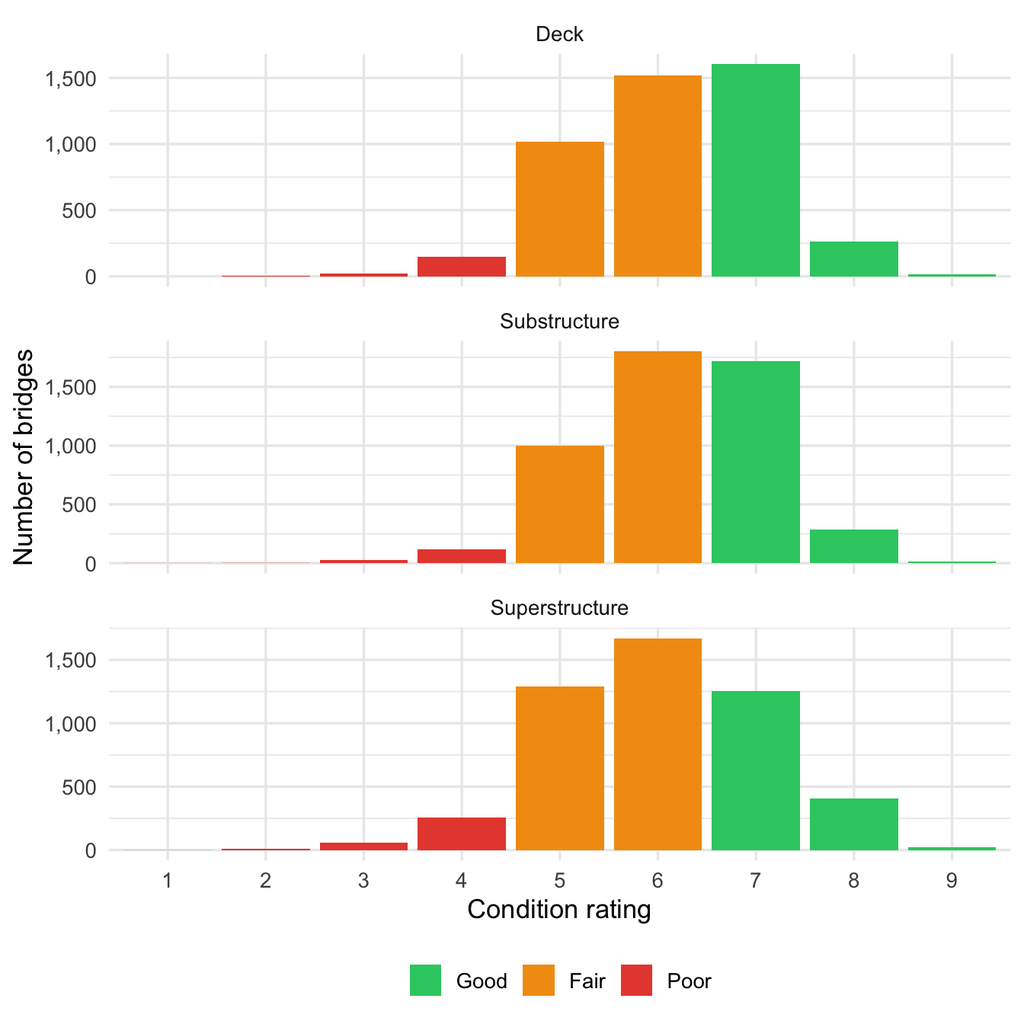

Figure 2: Rating distribution for each of the three structural components. Bridges rated N (not applicable, e.g. culverts) are excluded.

Table 1: Percentage of bridges in each condition band by component (N-rated excluded).

| Component | Poor | % Poor | Fair | % Fair | Good | % Good |
| --- | --- | --- | --- | --- | --- | --- |
| Deck | 169 | 3.7% | 2540 | 55.3% | 1881 | 41.0% |
| Superstructure | 326 | 6.6% | 2963 | 59.6% | 1681 | 33.8% |
| Substructure | 150 | 3.0% | 2805 | 56.4% | 2016 | 40.6% |

## Condition by County

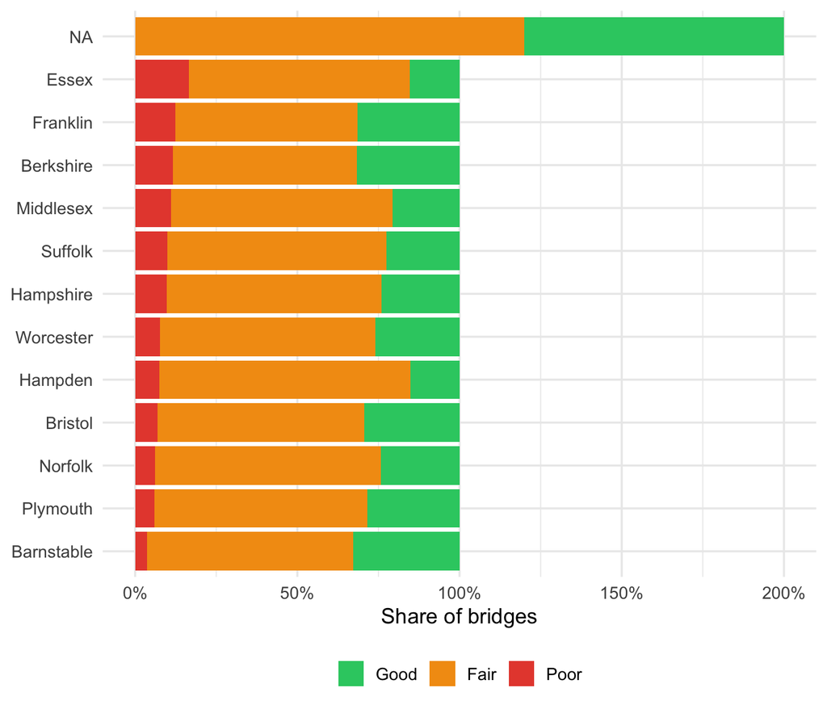

Figure 3: Bridge condition by county, ordered by percentage rated Poor.

Essex County has the highest share of Poor-rated bridges at **16.6%**, followed by Franklin (12.4%) and Berkshire (11.6%). More rural counties with older infrastructure tend to have higher rates of deterioration.

## Age and Condition

The median Massachusetts bridge was built in **1961**, with a quarter of the inventory dating from before **1948**. Bridges built in the 1920s and 1930s have the highest Poor rates.

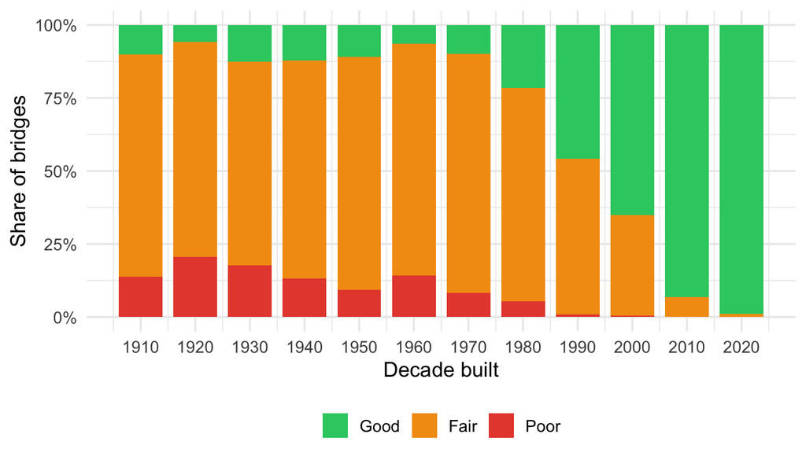

Figure 4: Percentage of bridges rated Poor, by decade of construction (1910–2020s).

## High-Priority Concerns

The 15 Poor-rated bridges carrying the most daily traffic represent an urgent maintenance priority, as failures would affect large numbers of commuters.

Table 2: Top 15 Poor-rated bridges by average daily traffic (ADT).

| Route | Crosses | County | Built | ADT | Rating |
| --- | --- | --- | --- | --- | --- |
| ST 3 | HWY UNION ST N ROTARY | Norfolk | 1957 | 204,310 | 4 |
| I 93 | I 95 /ST128 | Middlesex | 1957 | 200,824 | 4 |
| I 95 /ST128 | RR MBTA/BMRR | Middlesex | 1950 | 192,672 | 4 |
| I 93 | ST 16 MYST VAL PKY | Middlesex | 1960 | 182,420 | 4 |
| I 95 ST128 | HWY QUINOBEQUIN RD | Middlesex | 1950 | 142,579 | 4 |
| US 1 NEWBRPRT TPK | I 95 /ST128 | Essex | 1963 | 140,655 | 4 |
| I 495 | HWY MASSACHUSETTS AVE | Essex | 1963 | 124,334 | 4 |
| I 93 | WATER MERRIMACK RIVER | Essex | 1959 | 119,818 | 4 |
| I 90 | RR CSX | Middlesex | 1957 | 114,872 | 4 |
| I 93 NB/US1SB | ST 24 NB | Norfolk | 1958 | 101,100 | 4 |
| ST 9 BOYLSTON ST | TR GREEN LINE D | Middlesex | 1905 | 96,206 | 4 |
| I 495 SB | ST 28 SB/N MAIN ST | Essex | 1962 | 95,100 | 4 |
| I 95 SB/ST128 SB | ST 3 A/CAMBRIDGE ST | Middlesex | 1950 | 93,600 | 4 |
| I 495 SB | COMB BMRR & LITTLE RIV | Essex | 1961 | 93,469 | 4 |
| I 495 NB | COMB BMRR & LITTLE RIV | Essex | 1961 | 93,469 | 4 |

**Note**

**109 bridges** have a component rating of 3 (Serious) or below, indicating local failures are possible or the bridge is at imminent risk. These require the most urgent attention.

## Summary

| Metric | Value |
| --- | --- |
| Total bridges | 5,311 |
| Good condition | 1,291 (24.3%) |
| Fair condition | 3,519 (66.3%) |
| Poor condition | 501 (9.4%) |
| Serious or worse (rating ≤ 3) | 109 |
| Median year built | 1961 |
| County with most Poor bridges | Essex (16.6%) |

*Data source: Federal Highway Administration National Bridge Inventory, 2025.*